# Problem Statement:

A wholesale distributor operating in different regions of Portugal has information on annual spending of several items in their stores across different regions and channels. The data consists of 440 large retailers’ annual spending on 6 different varieties of products in 3 different regions (Lisbon, Oporto, Other) and across different sales channel (Hotel, Retail).

# Import all the necessary libraries

```python
import numpy as np
import pandas as pd
from matplotlib import pyplot as plt
%matplotlib inline
import seaborn as sns
import statsmodels.api as sm
import scipy.stats as stats
import copy
import os
```

## Load the data

```python
wholesale_customer_df = pd.read_csv('Wholesale+Customers+Data.csv')
```

```python
wholesale_customer_df.head()
```

|  | Buyer/Spender | Channel | Region | Fresh | Milk | Grocery | Frozen | Detergents_Paper | Delicatessen |
| --- | --- | --- | --- | --- | --- | --- | --- | --- | --- |
| 0 | 1 | Retail | Other | 12669 | 9656 | 7561 | 214 | 2674 | 1338 |
| 1 | 2 | Retail | Other | 7057 | 9810 | 9568 | 1762 | 3293 | 1776 |
| 2 | 3 | Retail | Other | 6353 | 8808 | 7684 | 2405 | 3516 | 7844 |
| 3 | 4 | Hotel | Other | 13265 | 1196 | 4221 | 6404 | 507 | 1788 |
| 4 | 5 | Retail | Other | 22615 | 5410 | 7198 | 3915 | 1777 | 5185 |

## Sumary of the dataset

```python
wholesale_customer_df.info()
```

```
<class 'pandas.core.frame.DataFrame'>
RangeIndex: 440 entries, 0 to 439
Data columns (total 9 columns):
 #   Column            Non-Null Count  Dtype
---  ------            --------------  -----
 0   Buyer/Spender     440 non-null    int64
 1   Channel           440 non-null    object
 2   Region            440 non-null    object
 3   Fresh             440 non-null    int64
 4   Milk              440 non-null    int64
 5   Grocery           440 non-null    int64
 6   Frozen            440 non-null    int64
 7   Detergents_Paper  440 non-null    int64
 8   Delicatessen      440 non-null    int64
dtypes: int64(7), object(2)
memory usage: 31.1+ KB
```

```python
wholesale_customer_df.shape
```

```
(440, 9)
```

## Check for missing value

```python
wholesale_customer_df.isnull().sum()
```

```
Buyer/Spender       0
Channel             0
Region              0
Fresh               0
Milk                0
Grocery             0
Frozen              0
Detergents_Paper    0
Delicatessen        0
dtype: int64
```

- There are no null values in any of the column

## Region Count

```python
wholesale_customer_df['Region'].value_counts()
```

```
Other     316
Lisbon     77
Oporto     47
Name: Region, dtype: int64
```

## Channel Count

```python
wholesale_customer_df['Channel'].value_counts()
```

```
Hotel     298
Retail    142
Name: Channel, dtype: int64
```

## 1.1 Use methods of descriptive statistics to summarize data. Which Region and which Channel spent the most? Which Region and which Channel spent the least?

## Checking the summary of dataframe

```python
wholesale_customer_df.describe(include = 'all').T
```

|  | count | unique | top | freq | mean | std | min | 25% | 50% | 75% | max |
| --- | --- | --- | --- | --- | --- | --- | --- | --- | --- | --- | --- |
| Buyer/Spender | 440.0 | NaN | NaN | NaN | 220.5 | 127.161315 | 1.0 | 110.75 | 220.5 | 330.25 | 440.0 |
| Channel | 440 | 2 | Hotel | 298 | NaN | NaN | NaN | NaN | NaN | NaN | NaN |
| Region | 440 | 3 | Other | 316 | NaN | NaN | NaN | NaN | NaN | NaN | NaN |
| Fresh | 440.0 | NaN | NaN | NaN | 12000.297727 | 12647.328865 | 3.0 | 3127.75 | 8504.0 | 16933.75 | 112151.0 |
| Milk | 440.0 | NaN | NaN | NaN | 5796.265909 | 7380.377175 | 55.0 | 1533.0 | 3627.0 | 7190.25 | 73498.0 |
| Grocery | 440.0 | NaN | NaN | NaN | 7951.277273 | 9503.162829 | 3.0 | 2153.0 | 4755.5 | 10655.75 | 92780.0 |
| Frozen | 440.0 | NaN | NaN | NaN | 3071.931818 | 4854.673333 | 25.0 | 742.25 | 1526.0 | 3554.25 | 60869.0 |
| Detergents_Paper | 440.0 | NaN | NaN | NaN | 2881.493182 | 4767.854448 | 3.0 | 256.75 | 816.5 | 3922.0 | 40827.0 |
| Delicatessen | 440.0 | NaN | NaN | NaN | 1524.870455 | 2820.105937 | 3.0 | 408.25 | 965.5 | 1820.25 | 47943.0 |

```python
print('Descriptive Statastics of our Data including Channel & Retail:')
wholesale_customer_df.describe(include='all').T
```

```
Descriptive Statastics of our Data including Channel & Retail:
```

|  | count | unique | top | freq | mean | std | min | 25% | 50% | 75% | max |
| --- | --- | --- | --- | --- | --- | --- | --- | --- | --- | --- | --- |
| Buyer/Spender | 440.0 | NaN | NaN | NaN | 220.5 | 127.161315 | 1.0 | 110.75 | 220.5 | 330.25 | 440.0 |
| Channel | 440 | 2 | Hotel | 298 | NaN | NaN | NaN | NaN | NaN | NaN | NaN |
| Region | 440 | 3 | Other | 316 | NaN | NaN | NaN | NaN | NaN | NaN | NaN |
| Fresh | 440.0 | NaN | NaN | NaN | 12000.297727 | 12647.328865 | 3.0 | 3127.75 | 8504.0 | 16933.75 | 112151.0 |
| Milk | 440.0 | NaN | NaN | NaN | 5796.265909 | 7380.377175 | 55.0 | 1533.0 | 3627.0 | 7190.25 | 73498.0 |
| Grocery | 440.0 | NaN | NaN | NaN | 7951.277273 | 9503.162829 | 3.0 | 2153.0 | 4755.5 | 10655.75 | 92780.0 |
| Frozen | 440.0 | NaN | NaN | NaN | 3071.931818 | 4854.673333 | 25.0 | 742.25 | 1526.0 | 3554.25 | 60869.0 |
| Detergents_Paper | 440.0 | NaN | NaN | NaN | 2881.493182 | 4767.854448 | 3.0 | 256.75 | 816.5 | 3922.0 | 40827.0 |
| Delicatessen | 440.0 | NaN | NaN | NaN | 1524.870455 | 2820.105937 | 3.0 | 408.25 | 965.5 | 1820.25 | 47943.0 |

```python
wholesale_customer_df.groupby(['Region', 'Channel']).size()
```

```
Region  Channel
Lisbon  Hotel       59
        Retail      18
Oporto  Hotel       28
        Retail      19
Other   Hotel      211
        Retail     105
dtype: int64
```

```python
wholesale_customer_dfnew = wholesale_customer_df.drop(['Buyer/Spender'], axis= 1)
wholesale_customer_dfnew.head()
```

|  | Channel | Region | Fresh | Milk | Grocery | Frozen | Detergents_Paper | Delicatessen |
| --- | --- | --- | --- | --- | --- | --- | --- | --- |
| 0 | Retail | Other | 12669 | 9656 | 7561 | 214 | 2674 | 1338 |
| 1 | Retail | Other | 7057 | 9810 | 9568 | 1762 | 3293 | 1776 |
| 2 | Retail | Other | 6353 | 8808 | 7684 | 2405 | 3516 | 7844 |
| 3 | Hotel | Other | 13265 | 1196 | 4221 | 6404 | 507 | 1788 |
| 4 | Retail | Other | 22615 | 5410 | 7198 | 3915 | 1777 | 5185 |

```python
wholesale_customer_dfnew['Total'] = wholesale_customer_dfnew[['Fresh', 'Milk', 'Grocery', 'Frozen', 'Detergents_Paper', 'Delicatessen']].sum(axis=1)
wholesale_customer_dfnew.head()
```

|  | Channel | Region | Fresh | Milk | Grocery | Frozen | Detergents_Paper | Delicatessen | Total |
| --- | --- | --- | --- | --- | --- | --- | --- | --- | --- |
| 0 | Retail | Other | 12669 | 9656 | 7561 | 214 | 2674 | 1338 | 34112 |
| 1 | Retail | Other | 7057 | 9810 | 9568 | 1762 | 3293 | 1776 | 33266 |
| 2 | Retail | Other | 6353 | 8808 | 7684 | 2405 | 3516 | 7844 | 36610 |
| 3 | Hotel | Other | 13265 | 1196 | 4221 | 6404 | 507 | 1788 | 27381 |
| 4 | Retail | Other | 22615 | 5410 | 7198 | 3915 | 1777 | 5185 | 46100 |

```python
results1 = wholesale_customer_dfnew.groupby(['Region','Channel']).sum().reset_index()
results1
```

|  | Region | Channel | Fresh | Milk | Grocery | Frozen | Detergents_Paper | Delicatessen | Total |
| --- | --- | --- | --- | --- | --- | --- | --- | --- | --- |
| 0 | Lisbon | Hotel | 761233 | 228342 | 237542 | 184512 | 56081 | 70632 | 1538342 |
| 1 | Lisbon | Retail | 93600 | 194112 | 332495 | 46514 | 148055 | 33695 | 848471 |
| 2 | Oporto | Hotel | 326215 | 64519 | 123074 | 160861 | 13516 | 30965 | 719150 |
| 3 | Oporto | Retail | 138506 | 174625 | 310200 | 29271 | 159795 | 23541 | 835938 |
| 4 | Other | Hotel | 2928269 | 735753 | 820101 | 771606 | 165990 | 320358 | 5742077 |
| 5 | Other | Retail | 1032308 | 1153006 | 1675150 | 158886 | 724420 | 191752 | 4935522 |

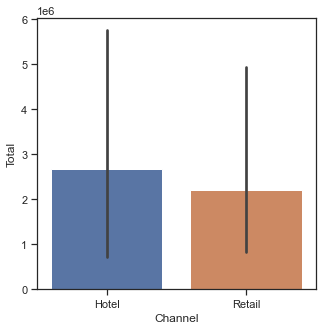

|  | Channel | Fresh | Milk | Grocery | Frozen | Detergents_Paper | Delicatessen | Total |
| --- | --- | --- | --- | --- | --- | --- | --- | --- |
| 0 | Hotel | 4015717 | 1028614 | 1180717 | 1116979 | 235587 | 421955 | 7999569 |
| 1 | Retail | 1264414 | 1521743 | 2317845 | 234671 | 1032270 | 248988 | 6619931 |

```python
plt.figure(figsize=(5,5))
sns.barplot(x=results1['Channel'], y=results1['Total'], data =results1);
plt.show()
wholesale_customer_dfnew.groupby('Channel',).sum().reset_index()
```

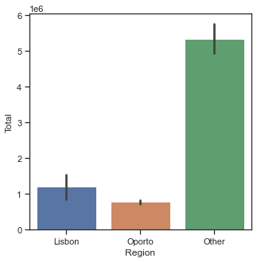

|  | Region | Fresh | Milk | Grocery | Frozen | Detergents_Paper | Delicatessen | Total |
| --- | --- | --- | --- | --- | --- | --- | --- | --- |
| 0 | Lisbon | 854833 | 422454 | 570037 | 231026 | 204136 | 104327 | 2386813 |
| 1 | Oporto | 464721 | 239144 | 433274 | 190132 | 173311 | 54506 | 1555088 |
| 2 | Other | 3960577 | 1888759 | 2495251 | 930492 | 890410 | 512110 | 10677599 |

```python
plt.figure(figsize=(5,5))
sns.barplot(x=results1['Region'], y=results1['Total'], data =results1);
plt.show()
wholesale_customer_dfnew.groupby('Region',).sum().reset_index()
```

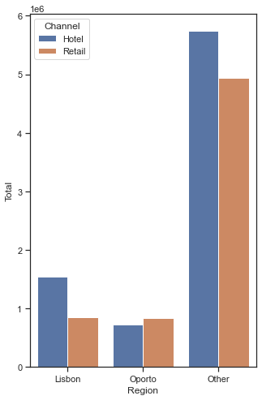

```python
plt.figure(figsize=(5,8))
sns.barplot(x=results1['Region'], y=results1['Total'], hue='Channel', data =results1);
plt.show()
```

## 1.2 There are 6 different varieties of items that are considered. Describe and comment/explain all the varieties across Region and Channel? Provide a detailed justification for your answer.

```python
results = wholesale_customer_dfnew.groupby('Region').sum()
resultsnew= results.drop(columns='Total')
resultsnew
```

| Region | Fresh | Milk | Grocery | Frozen | Detergents_Paper | Delicatessen |
| --- | --- | --- | --- | --- | --- | --- |
| Lisbon | 854833 | 422454 | 570037 | 231026 | 204136 | 104327 |
| Oporto | 464721 | 239144 | 433274 | 190132 | 173311 | 54506 |
| Other | 3960577 | 1888759 | 2495251 | 930492 | 890410 | 512110 |

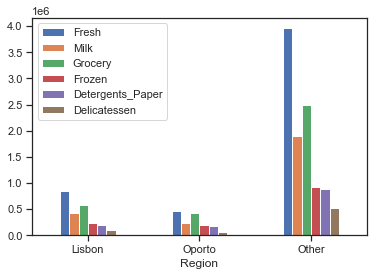

```python
resultsnew.plot.bar(rot=0);
```

```python
results = wholesale_customer_dfnew.groupby('Channel').sum()
results2 =results.drop(columns='Total')
results2
```

| Channel | Fresh | Milk | Grocery | Frozen | Detergents_Paper | Delicatessen |
| --- | --- | --- | --- | --- | --- | --- |
| Hotel | 4015717 | 1028614 | 1180717 | 1116979 | 235587 | 421955 |
| Retail | 1264414 | 1521743 | 2317845 | 234671 | 1032270 | 248988 |

1.3 based on a descriptive measure of variability, which item shows the most inconsistent behaviour? Which items show the least inconsistent behaviour?

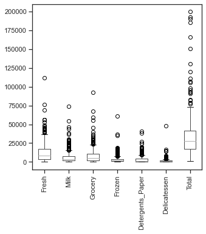

```python
plt.figure (figsize=(5,5))
wholesale_customer_dfnew.boxplot(fontsize=None,
    rot=90,
    grid=False);
plt.show()
```

```python
Q1 =wholesale_customer_dfnew.quantile(0.25)
Q3 = wholesale_customer_dfnew.quantile(0.75)
IQR = Q3 - Q1
print(IQR)
```

```
Fresh               13806.00
Milk                 5657.25
Grocery              8502.75
Frozen               2812.00
Detergents_Paper     3665.25
Delicatessen         1412.00
Total               23858.75
dtype: float64
```

```python
wholesale_customer_dfnew.std()
```

```
Fresh               12647.328865
Milk                 7380.377175
Grocery              9503.162829
Frozen               4854.673333
Detergents_Paper     4767.854448
Delicatessen         2820.105937
Total               26356.301730
dtype: float64
```

1.4 Are there any outliers in the data?

```python
wholesale_customer_dfnew = wholesale_customer_df.drop(['Buyer/Spender'], axis= 1)
wholesale_customer_dfnew.head()
```

|  | Channel | Region | Fresh | Milk | Grocery | Frozen | Detergents_Paper | Delicatessen |
| --- | --- | --- | --- | --- | --- | --- | --- | --- |
| 0 | Retail | Other | 12669 | 9656 | 7561 | 214 | 2674 | 1338 |
| 1 | Retail | Other | 7057 | 9810 | 9568 | 1762 | 3293 | 1776 |
| 2 | Retail | Other | 6353 | 8808 | 7684 | 2405 | 3516 | 7844 |
| 3 | Hotel | Other | 13265 | 1196 | 4221 | 6404 | 507 | 1788 |
| 4 | Retail | Other | 22615 | 5410 | 7198 | 3915 | 1777 | 5185 |

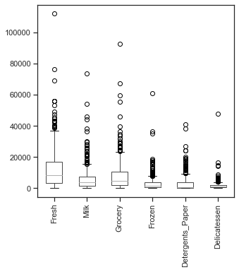

```python
plt.figure (figsize=(5,5))
wholesale_customer_dfnew.boxplot(fontsize=None,
    rot=90,
    grid=False);
plt.show()
```

```python
dfo = (wholesale_customer_dfnew < (Q1 - 1.5 * IQR)) |(wholesale_customer_dfnew > (Q3 + 1.5 * IQR))
dfo.head()
```

|  | Channel | Delicatessen | Detergents_Paper | Fresh | Frozen | Grocery | Milk | Region | Total |
| --- | --- | --- | --- | --- | --- | --- | --- | --- | --- |
| 0 | False | False | False | False | False | False | False | False | False |
| 1 | False | False | False | False | False | False | False | False | False |
| 2 | False | True | False | False | False | False | False | False | False |
| 3 | False | False | False | False | False | False | False | False | False |
| 4 | False | True | False | False | False | False | False | False | False |

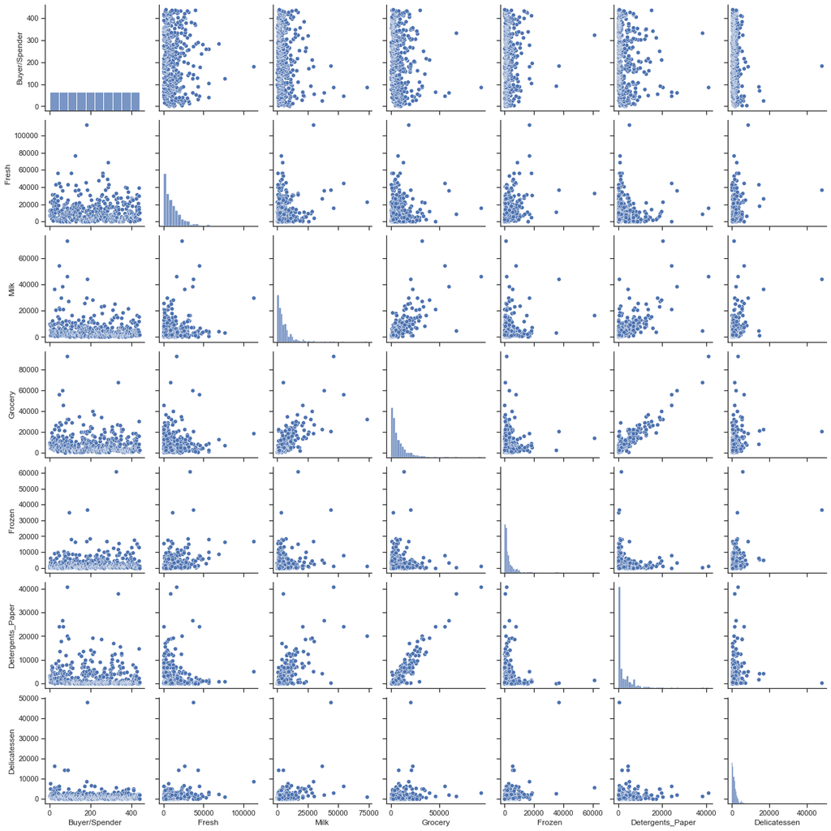

```python
sns.pairplot(wholesale_customer_df)  #pairplot
plt.show()
```

```python
corr = wholesale_customer_dfnew.corr()
corr
```

|  | Fresh | Milk | Grocery | Frozen | Detergents_Paper | Delicatessen |
| --- | --- | --- | --- | --- | --- | --- |
| Fresh | 1.000000 | 0.100510 | -0.011854 | 0.345881 | -0.101953 | 0.244690 |
| Milk | 0.100510 | 1.000000 | 0.728335 | 0.123994 | 0.661816 | 0.406368 |
| Grocery | -0.011854 | 0.728335 | 1.000000 | -0.040193 | 0.924641 | 0.205497 |
| Frozen | 0.345881 | 0.123994 | -0.040193 | 1.000000 | -0.131525 | 0.390947 |
| Detergents_Paper | -0.101953 | 0.661816 | 0.924641 | -0.131525 | 1.000000 | 0.069291 |
| Delicatessen | 0.244690 | 0.406368 | 0.205497 | 0.390947 | 0.069291 | 1.000000 |

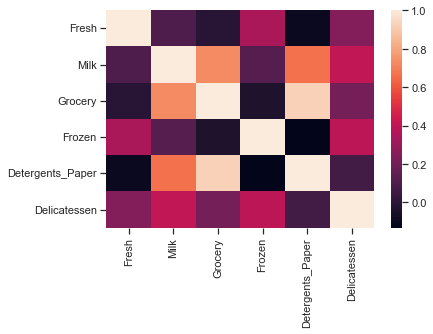

```python
sns.heatmap(corr)
```

## Problem 2 - The Student News Service at Clear Mountain State University (CMSU) has decided to gather data about the undergraduate students that attend CMSU. CMSU creates and distributes a survey of 14 questions and receives responses from 62 undergraduates (stored in the Survey data set).

## Load the data

```python
survey_df = pd.read_csv('Survey.csv')
```

```python
survey_df.head()
```

|  | ID | Gender | Age | Class | Major | Grad Intention | GPA | Employment | Salary | Social Networking | Satisfaction | Spending | Computer | Text Messages |
| --- | --- | --- | --- | --- | --- | --- | --- | --- | --- | --- | --- | --- | --- | --- |
| 0 | 1 | Female | 20 | Junior | Other | Yes | 2.9 | Full-Time | 50.0 | 1 | 3 | 350 | Laptop | 200 |
| 1 | 2 | Male | 23 | Senior | Management | Yes | 3.6 | Part-Time | 25.0 | 1 | 4 | 360 | Laptop | 50 |
| 2 | 3 | Male | 21 | Junior | Other | Yes | 2.5 | Part-Time | 45.0 | 2 | 4 | 600 | Laptop | 200 |
| 3 | 4 | Male | 21 | Junior | CIS | Yes | 2.5 | Full-Time | 40.0 | 4 | 6 | 600 | Laptop | 250 |
| 4 | 5 | Male | 23 | Senior | Other | Undecided | 2.8 | Unemployed | 40.0 | 2 | 4 | 500 | Laptop | 100 |

## Sumary of the dataset

```python
survey_df.info()
```

```
<class 'pandas.core.frame.DataFrame'>
RangeIndex: 62 entries, 0 to 61
Data columns (total 14 columns):
 #   Column             Non-Null Count  Dtype
---  ------             --------------  -----
 0   ID                 62 non-null     int64
 1   Gender             62 non-null     object
 2   Age                62 non-null     int64
 3   Class              62 non-null     object
 4   Major              62 non-null     object
 5   Grad Intention     62 non-null     object
 6   GPA                62 non-null     float64
 7   Employment         62 non-null     object
 8   Salary             62 non-null     float64
 9   Social Networking  62 non-null     int64
 10  Satisfaction       62 non-null     int64
 11  Spending           62 non-null     int64
 12  Computer           62 non-null     object
 13  Text Messages      62 non-null     int64
dtypes: float64(2), int64(6), object(6)
memory usage: 6.9+ KB
```

```python
survey_df.shape
```

```
(62, 14)
```

## Check for missing value

```python
survey_df.isnull().sum()
```

```
ID                   0
Gender               0
Age                  0
Class                0
Major                0
Grad Intention       0
GPA                  0
Employment           0
Salary               0
Social Networking    0
Satisfaction         0
Spending             0
Computer             0
Text Messages        0
dtype: int64
```

There are no null values in any of the column

```python
survey_df.describe(include="all").T
```

|  | count | unique | top | freq | mean | std | min | 25% | 50% | 75% | max |
| --- | --- | --- | --- | --- | --- | --- | --- | --- | --- | --- | --- |
| ID | 62.0 | NaN | NaN | NaN | 31.5 | 18.041619 | 1.0 | 16.25 | 31.5 | 46.75 | 62.0 |
| Gender | 62 | 2 | Female | 33 | NaN | NaN | NaN | NaN | NaN | NaN | NaN |
| Age | 62.0 | NaN | NaN | NaN | 21.129032 | 1.431311 | 18.0 | 20.0 | 21.0 | 22.0 | 26.0 |
| Class | 62 | 3 | Senior | 31 | NaN | NaN | NaN | NaN | NaN | NaN | NaN |
| Major | 62 | 8 | Retailing/Marketing | 14 | NaN | NaN | NaN | NaN | NaN | NaN | NaN |
| Grad Intention | 62 | 3 | Yes | 28 | NaN | NaN | NaN | NaN | NaN | NaN | NaN |
| GPA | 62.0 | NaN | NaN | NaN | 3.129032 | 0.377388 | 2.3 | 2.9 | 3.15 | 3.4 | 3.9 |
| Employment | 62 | 3 | Part-Time | 43 | NaN | NaN | NaN | NaN | NaN | NaN | NaN |
| Salary | 62.0 | NaN | NaN | NaN | 48.548387 | 12.080912 | 25.0 | 40.0 | 50.0 | 55.0 | 80.0 |
| Social Networking | 62.0 | NaN | NaN | NaN | 1.516129 | 0.844305 | 0.0 | 1.0 | 1.0 | 2.0 | 4.0 |
| Satisfaction | 62.0 | NaN | NaN | NaN | 3.741935 | 1.213793 | 1.0 | 3.0 | 4.0 | 4.0 | 6.0 |
| Spending | 62.0 | NaN | NaN | NaN | 482.016129 | 221.953805 | 100.0 | 312.5 | 500.0 | 600.0 | 1400.0 |
| Computer | 62 | 3 | Laptop | 55 | NaN | NaN | NaN | NaN | NaN | NaN | NaN |
| Text Messages | 62.0 | NaN | NaN | NaN | 246.209677 | 214.46595 | 0.0 | 100.0 | 200.0 | 300.0 | 900.0 |

```
array([[<AxesSubplot:title={'center':'ID'}>,
        <AxesSubplot:title={'center':'Age'}>,
        <AxesSubplot:title={'center':'GPA'}>],
       [<AxesSubplot:title={'center':'Salary'}>,
        <AxesSubplot:title={'center':'Social Networking'}>,
        <AxesSubplot:title={'center':'Satisfaction'}>],
       [<AxesSubplot:title={'center':'Spending'}>,
        <AxesSubplot:title={'center':'Text Messages'}>, <AxesSubplot:>]],
      dtype=object)
```

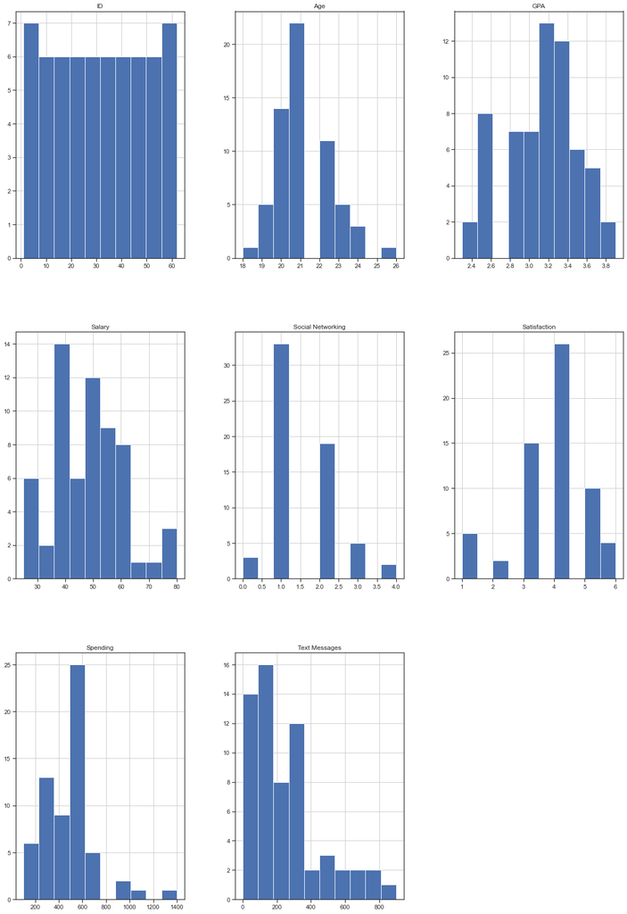

```python
import matplotlib.pyplot as plt
%matplotlib inline

survey_df.hist(figsize=(20,30))
```

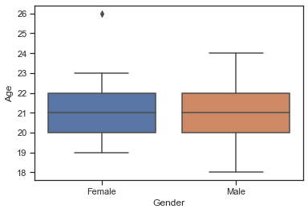

```python
sns.boxplot(x="Gender", y="Age", data=survey_df)
```

2.1. For this data, construct the following contingency tables (Keep Gender as row variable)

2.1.1. Gender and Major

```python
pd.crosstab(survey_df['Gender'],survey_df['Major'] )
```

| Major Gender | Accounting | CIS | Economics/Finance | International Business | Management | Other | Retailing/Marketing | Undecided |
| --- | --- | --- | --- | --- | --- | --- | --- | --- |
| Female | 3 | 3 | 7 | 4 | 4 | 3 | 9 | 0 |
| Male | 4 | 1 | 4 | 2 | 6 | 4 | 5 | 3 |

2.1.2. Gender and Grad Intention

```python
pd.crosstab(survey_df['Gender'],survey_df['Grad Intention'] )
```

| Grad Intention Gender | No | Undecided | Yes |
| --- | --- | --- | --- |
| Female | 9 | 13 | 11 |
| Male | 3 | 9 | 17 |

2.1.3. Gender and Employment

```python
pd.crosstab(survey_df['Gender'],survey_df['Employment'] )
```

| Employment Gender | Full-Time | Part-Time | Unemployed |
| --- | --- | --- | --- |
| Female | 3 | 24 | 6 |
| Male | 7 | 19 | 3 |

2.1.4. Gender and Computer

```python
pd.crosstab(survey_df['Gender'],survey_df['Computer'] )
```

| Computer Gender | Desktop | Laptop | Tablet |
| --- | --- | --- | --- |
| Female | 2 | 29 | 2 |
| Male | 3 | 26 | 0 |

2.2. Assume that the sample is representative of the population of CMSU. Based on the data, answer the following question:

2.2.1. What is the probability that a randomly selected CMSU student will be male?

```python
survey_df.describe().T
```

|  | count | mean | std | min | 25% | 50% | 75% | max |
| --- | --- | --- | --- | --- | --- | --- | --- | --- |
| ID | 62.0 | 31.500000 | 18.041619 | 1.0 | 16.25 | 31.50 | 46.75 | 62.0 |
| Age | 62.0 | 21.129032 | 1.431311 | 18.0 | 20.00 | 21.00 | 22.00 | 26.0 |
| GPA | 62.0 | 3.129032 | 0.377388 | 2.3 | 2.90 | 3.15 | 3.40 | 3.9 |
| Salary | 62.0 | 48.548387 | 12.080912 | 25.0 | 40.00 | 50.00 | 55.00 | 80.0 |
| Social Networking | 62.0 | 1.516129 | 0.844305 | 0.0 | 1.00 | 1.00 | 2.00 | 4.0 |
| Satisfaction | 62.0 | 3.741935 | 1.213793 | 1.0 | 3.00 | 4.00 | 4.00 | 6.0 |
| Spending | 62.0 | 482.016129 | 221.953805 | 100.0 | 312.50 | 500.00 | 600.00 | 1400.0 |
| Text Messages | 62.0 | 246.209677 | 214.465950 | 0.0 | 100.00 | 200.00 | 300.00 | 900.0 |

```python
survey_df['Gender'].value_counts()
```

```
Female    33
Male      29
Name: Gender, dtype: int64
```

```python
No_of_male = (survey_df['Gender'] =='Male').sum()
print(No_of_male)
No_of_female = (survey_df['Gender'] =='Female').sum()
print(No_of_female)
Total_value =survey_df['Gender'].value_counts().sum()
print(Total_value)
```

```
29
33
62
```

```python
p_male = No_of_male/Total_value

print('The probability that a randomly selected CMSU student will be male',(p_male)*100)
```

```
The probability that a randomly selected CMSU student will be male 46.774193548387096
```

2.2.2. What is the probability that a randomly selected CMSU student will be female?

```python
p_female= No_of_female/Total_value

print('The probability that a randomly selected CMSU student will be male',(p_female)*100)
```

```
The probability that a randomly selected CMSU student will be male 53.2258064516129
```